# R Notebook

# 1. Introduction

Throughout this project, we plan to employ a range of statistical tools and machine learning models to analyze our dataset. The objective is to identify and select the most effective solution for addressing our specific problem. By utilizing a combination of statistical methodologies and advanced machine learning techniques, we aim to gain valuable insights and make informed decisions regarding the dataset’s characteristics.

```r
library(caret)
library(dplyr)
library(ggplot2)
library(gridExtra)
library(pdp)
```

# 2. Data preprocessing

The dataset utilized for the project objective is sourced from the Global Health Observatory (GHO) data repository maintained by the World Health Organization (WHO). Specifically, this dataset focuses on life expectancy and includes health-related factors for 193 countries, obtained from the WHO data repository. Corresponding economic data was gathered from the United Nations website.

From the broad spectrum of health-related factors, only critical variables from the years 2000 to 2015 were selected to create a more representative dataset. The resulting dataset comprises 22 columns and 2938 rows, featuring 20 predictive variables, namely: Country, Year, Status, Life Expectancy, Adult Mortality, Infant Deaths, Alcohol, Percentage Expenditure, Hepatitis B, Measles, BMI, Under-Five Deaths, Polio, Total Expenditure, Diphtheria, HIV/AIDS, GDP, Population, Thinness 1-19 years, Thinness 5-9 years, Income Composition of Resources, and Schooling.

The dataset has been selected from kaggle: https://www.kaggle.com/datasets/kumarajarshi/life-expectancy-who

```r
data <- read.csv("Life Expectancy Data.csv")

#we set seed for reproducibility
set.seed(123)

# split between training and testing sets
spl = createDataPartition(data$Year, p = 0.8, list = FALSE)  # 80% for training

Train = data[spl,]
Test = data[-spl,]


str(Train)
```

```
'data.frame':   2352 obs. of  22 variables:
 $ Country                        : chr  "Afghanistan" "Afghanistan" "Afghanistan" "Afghanistan" ...
 $ Year                           : int  2015 2014 2013 2011 2010 2009 2008 2007 2005 2003 ...
 $ Status                         : chr  "Developing" "Developing" "Developing" "Developing" ...
 $ Life.expectancy                : num  65 59.9 59.9 59.2 58.8 58.6 58.1 57.5 57.3 56.7 ...
 $ Adult.Mortality                : int  263 271 268 275 279 281 287 295 291 295 ...
 $ infant.deaths                  : int  62 64 66 71 74 77 80 82 85 87 ...
 $ Alcohol                        : num  0.01 0.01 0.01 0.01 0.01 0.01 0.03 0.02 0.02 0.01 ...
 $ percentage.expenditure         : num  71.3 73.5 73.2 7.1 79.7 ...
 $ Hepatitis.B                    : int  65 62 64 68 66 63 64 63 66 65 ...
 $ Measles                        : int  1154 492 430 3013 1989 2861 1599 1141 1296 798 ...
 $ BMI                            : num  19.1 18.6 18.1 17.2 16.7 16.2 15.7 15.2 14.2 13.4 ...
 $ under.five.deaths              : int  83 86 89 97 102 106 110 113 118 122 ...
 $ Polio                          : int  6 58 62 68 66 63 64 63 58 41 ...
 $ Total.expenditure              : num  8.16 8.18 8.13 7.87 9.2 9.42 8.33 6.73 8.7 8.82 ...
 $ Diphtheria                     : int  65 62 64 68 66 63 64 63 58 41 ...
 $ HIV.AIDS                       : num  0.1 0.1 0.1 0.1 0.1 0.1 0.1 0.1 0.1 0.1 ...
 $ GDP                            : num  584.3 612.7 631.7 63.5 553.3 ...
 $ Population                     : num  33736494 327582 31731688 2978599 2883167 ...
 $ thinness..1.19.years           : num  17.2 17.5 17.7 18.2 18.4 18.6 18.8 19 19.3 19.7 ...
 $ thinness.5.9.years             : num  17.3 17.5 17.7 18.2 18.4 18.7 18.9 19.1 19.5 19.9 ...
 $ Income.composition.of.resources: num  0.479 0.476 0.47 0.454 0.448 0.434 0.433 0.415 0.396 0.373 ...
 $ Schooling                      : num  10.1 10 9.9 9.5 9.2 8.9 8.7 8.4 7.9 6.5 ...
```

As we can observe, most of the variables are numerical or integer, having only two categorical variables. On the following sections we will deeply understand these variables, the missing values, ranges of values and number of categories.

## 2.1. Missing values

As an initial step, we examine the potential null values within the dataset. Many features exhibit some null values, and for some, the quantity is notably high. Consequently, we have chosen to tackle this issue by removing rows for features with fewer than a hundred nulls. However, for the remaining features, we will address the null values by replacing them with the mean of each respective variable.

```r
sum(is.na(Train$Country))
```

```
[1] 0
```

```r
sum(is.na(Train$Year))
```

```
[1] 0
```

```r
sum(is.na(Train$Status))
```

```
[1] 0
```

```r
sum(is.na(Train$Life.expectancy))
```

```
[1] 8
```

```r
sum(is.na(Train$Adult.Mortality))
```

```
[1] 8
```

```r
sum(is.na(Train$infant.deaths))
```

```
[1] 0
```

```r
sum(is.na(Train$percentage.expenditure))
```

```
[1] 0
```

```r
sum(is.na(Train$Measles))
```

```
[1] 0
```

```r
sum(is.na(Train$BMI))
```

```
[1] 28
```

```r
sum(is.na(Train$under.five.deaths))
```

```
[1] 0
```

```r
sum(is.na(Train$Polio))
```

```
[1] 13
```

```r
sum(is.na(Train$Diphtheria))
```

```
[1] 13
```

```r
sum(is.na(Train$HIV.AIDS))
```

```
[1] 0
```

```r
sum(is.na(Train$thinness..1.19.years))
```

```
[1] 28
```

```r
sum(is.na(Train$thinness.5.9.years))
```

```
[1] 28
```

```r
sum(is.na(Train$Alcohol))######
```

```
[1] 157
```

```r
sum(is.na(Train$Hepatitis.B))#####
```

```
[1] 452
```

```r
sum(is.na(Train$Total.expenditure))####
```

```
[1] 185
```

```r
sum(is.na(Train$GDP))####
```

```
[1] 371
```

```r
sum(is.na(Train$Population))#####
```

```
[1] 539
```

```r
sum(is.na(Train$Income.composition.of.resources))####
```

```
[1] 138
```

```r
sum(is.na(Train$Schooling))####
```

```
[1] 136
```

First step, we remove the rows of the features with small quantity of nulls.

```r
# Remove rows with missing values in specified columns
Train <- Train[complete.cases(Train$Life.expectancy, Train$Adult.Mortality, Train$BMI,
                              Train$Polio, Train$Diphtheria, Train$thinness..1.19.years,
                              Train$thinness.5.9.years), ]

# Check for missing values after removal
sum(is.na(Train$Life.expectancy))
```

```
[1] 0
```

```r
sum(is.na(Train$Adult.Mortality))
```

```
[1] 0
```

```r
sum(is.na(Train$BMI))
```

```
[1] 0
```

```r
sum(is.na(Train$Polio))
```

```
[1] 0
```

```r
sum(is.na(Train$Diphtheria))
```

```
[1] 0
```

```r
sum(is.na(Train$thinness..1.19.years))
```

```
[1] 0
```

```r
sum(is.na(Train$thinness.5.9.years))
```

```
[1] 0
```

Second step, we replace by the mean on the rest of the null values.

```r
# Replace missing values with the mean for specified columns
Train <- Train %>%
  mutate_all(~ifelse(is.na(.), mean(., na.rm = TRUE), .))



sum(is.na(Train$Alcohol))######
```

```
[1] 0
```

```r
sum(is.na(Train$Hepatitis.B))#####
```

```
[1] 0
```

```r
sum(is.na(Train$Total.expenditure))####
```

```
[1] 0
```

```r
sum(is.na(Train$GDP))####
```

```
[1] 0
```

```r
sum(is.na(Train$Population))#####
```

```
[1] 0
```

```r
sum(is.na(Train$Income.composition.of.resources))####
```

```
[1] 0
```

```r
sum(is.na(Train$Schooling))####
```

```
[1] 0
```

Finally, our training dataset is free of null values.

```r
sum(is.na(Train))
```

```
[1] 0
```

Next, it is necessary to replicate the procedure for the test set to ensure the ability to make predictions later. Here, we will adopt the same approach, removing rows for the same features as performed in the training set. For the remaining null values in the test set, we will replace them with the means calculated from the training set to prevent data leakage from the test set into the predictions.

```r
sum(is.na(Test$Life.expectancy))
```

```
[1] 2
```

```r
sum(is.na(Test$Adult.Mortality))
```

```
[1] 2
```

```r
sum(is.na(Test$Alcohol))
```

```
[1] 37
```

```r
sum(is.na(Test$Hepatitis.B))
```

```
[1] 101
```

```r
sum(is.na(Test$BMI))
```

```
[1] 6
```

```r
sum(is.na(Test$Polio))
```

```
[1] 6
```

```r
sum(is.na(Test$Diphtheria))
```

```
[1] 6
```

```r
sum(is.na(Test$GDP))
```

```
[1] 77
```

```r
sum(is.na(Test$Population))
```

```
[1] 113
```

```r
sum(is.na(Test$thinness..1.19.years))
```

```
[1] 6
```

```r
sum(is.na(Test$thinness.5.9.years))
```

```
[1] 6
```

```r
sum(is.na(Test$Income.composition.of.resources))
```

```
[1] 29
```

```r
sum(is.na(Test$Schooling))
```

```
[1] 27
```

```r
# Remove rows with missing values in specified columns
Test <- Test[complete.cases(Test$Life.expectancy, Test$Adult.Mortality, Test$BMI,
                              Test$Polio, Test$Diphtheria, Test$thinness..1.19.years,
                              Test$thinness.5.9.years), ]

# Check for missing values after removal
sum(is.na(Test$Life.expectancy))
```

```
[1] 0
```

```r
sum(is.na(Test$Adult.Mortality))
```

```
[1] 0
```

```r
sum(is.na(Test$BMI))
```

```
[1] 0
```

```r
sum(is.na(Test$Polio))
```

```
[1] 0
```

```r
sum(is.na(Test$Diphtheria))
```

```
[1] 0
```

```r
sum(is.na(Test$thinness..1.19.years))
```

```
[1] 0
```

```r
sum(is.na(Test$thinness.5.9.years))
```

```
[1] 0
```

```r
# Identify numerical columns in Train
numerical_columns <- sapply(Train, is.numeric)

# Calculate means for numerical columns
train_means <- colMeans(Train[, numerical_columns], na.rm = TRUE)

# Replace missing values in the Test set with the means from the Train set
Test <- Test %>%
  mutate(across(where(is.numeric), ~ifelse(is.na(.), train_means[match(cur_column(), names(train_means))], .)))

sum(is.na(Test))
```

```
[1] 0
```

## 2.2. Numerical variables

On this section we will evaluate the distributions of all the numerical variables for better understanding the dataset. As we can observe, some of the variables has the presence of many outliers, however, this could be explain due to the nature of them:

- **Infant Deaths and Under-Five Deaths**: these variables involve human lives, and in some regions or specific cases, there may be occurrences of unusually high infant or under-five mortality rates due to factors such as epidemics, lack of healthcare infrastructure, or socio-economic conditions.
- **Percentage Expenditure, GDP, and Population**: economic indicators like Percentage Expenditure, GDP, and Population can be influenced by extreme events such as economic crises, natural disasters, or rapid population growth. Outliers in these variables may reflect unique economic situations in specific countries or years.
- **Hepatitis B, Measles, Polio, HIV/AIDS**: these variables are related to diseases and vaccination rates. Outliers may occur due to outbreaks, vaccination campaigns, or specific health policies implemented in certain regions or time periods. Additionally, some countries may have higher prevalence rates for certain diseases.

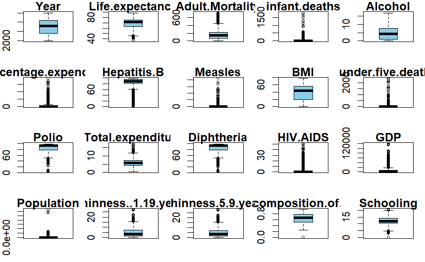

```r
Train <- Train %>%   dplyr::select(Country, Status, everything())

par(mfrow=c(4, 5),  mar = c(2, 2, 1, 1))  # Adjust the layout based on the number of variables
for (col in names(Train[,c(3:22)])) {
  boxplot(Train[, col], main=col, col="skyblue", border="black")
}
```

## 2.3. Categorical variables

Within the set of categorical variables, there are two distinct yet interconnected ones. “Country” encompasses numerous categories, posing the risk of overfitting the model due to its high dimensionality. In contrast, “Status” has only two categories and effectively encapsulates crucial information from the “Country” variable. It serves as a concise summary, highlighting a fundamental characteristic in this context—whether the countries are developed or developing. Consequently, opting for “Status” in the final model might prove more advantageous than utilizing “Country.”

```r
cat("Country:", table(Train$Country) , "\n")
```

```
Country: 12 13 12 12 13 11 13 15 12 15 13 16 13 10 14 13 12 12 14 12 12 8 14 14 13 14 12 13 7 12 13 13 12 15 14 9 14 13 11 12 15 15 10 13 14 12 14 15 13 12 12 11 12 12 12 14 12 14 12 13 16 13 14 15 9 14 13 14 11 15 13 12 14 12 12 14 11 15 14 12 12 13 15 13 12 13 11 14 14 15 12 11 12 13 14 13 9 12 11…
```

```r
cat("Status:",table(Train$Status), "\n")
```

```
Status: 413 1899
```

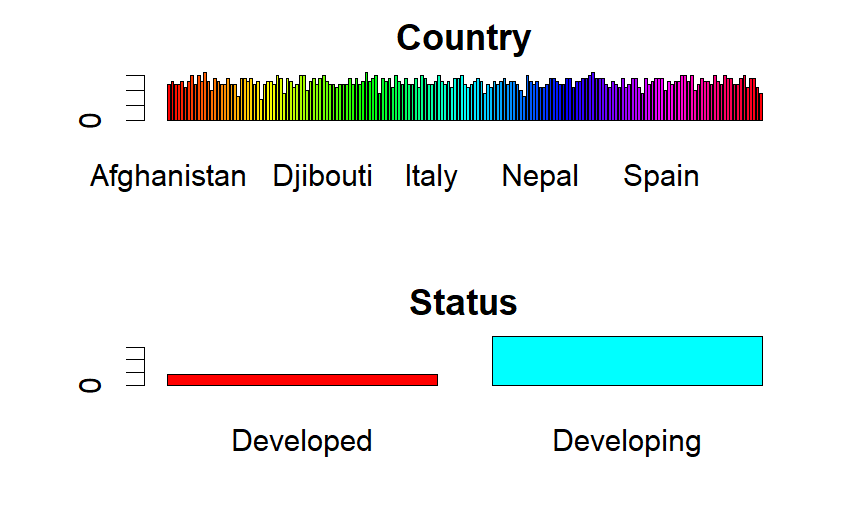

```r
# Assuming Train is a data frame with the specified columns
# Create a list of variables
variables <- c("Country", "Status")

# Set up the plotting area
par(mfrow = c(2, 1), mar = c(4, 4, 2, 2))  # Adjust the margins as needed

# Loop through each variable and create a bar chart
for (variable in variables) {
  # Count occurrences of each category
  variable_counts <- table(Train[[variable]])

  # Create a bar chart
  barplot(variable_counts, main = variable, col = rainbow(length(variable_counts)))
}

# Reset the plotting area
par(mfrow = c(1, 1))
```

```r
NA
NA
```

## 2.4. Descriptive analysis

Having scrutinized the majority of features, our attention is now directed towards the target variable. “Life Expectancy” is a continuous numerical variable that, as illustrated in the plot, exhibits a left-skewed distribution. Despite experimenting with various transformations, none of them proves effective in achieving symmetry for the variable. Consequently, we have decided to retain and utilize the variable in its original, natural form for further analysis.

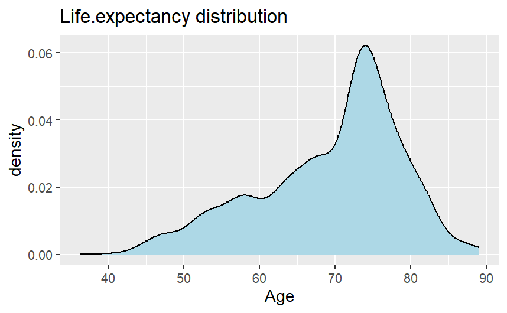

```r
ggplot(Train, aes(Life.expectancy)) + geom_density(fill="lightblue") + xlab("Age") + ggtitle("Life.expectancy distribution")
```

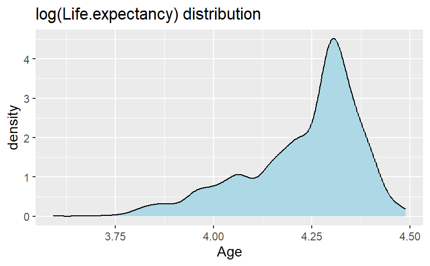

```r
ggplot(Train, aes(log(Life.expectancy))) + geom_density(fill="lightblue") + xlab("Age") + ggtitle("log(Life.expectancy) distribution")
```

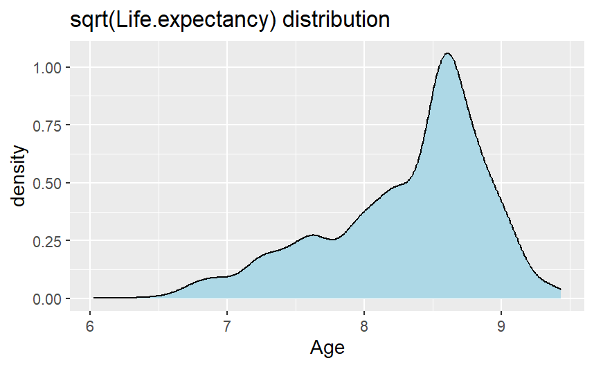

```r
ggplot(Train, aes(sqrt(Life.expectancy))) + geom_density(fill="lightblue") + xlab("Age") + ggtitle("sqrt(Life.expectancy) distribution")
```

## 2.5. Exploratory data analysis

In the upcoming section, we’ll conduct a detailed analysis of the remaining variables concerning our objective feature. To better grasp potential relationships, we’ll begin by assessing the marginal correlation of each variable with the target. Subsequently, we’ll focus on the more correlated variables and explore some regression approximations.

#### Correlations

Examining the marginal correlations reveals that addressing this problem could be straightforward, given the high correlation of many variables with the target. This suggests the possibility of achieving strong predictions using just one variable. However, it is essential to consider inter-variable relationships as well, as they could provide valuable insights, potentially enhancing the accuracy of our predictions.

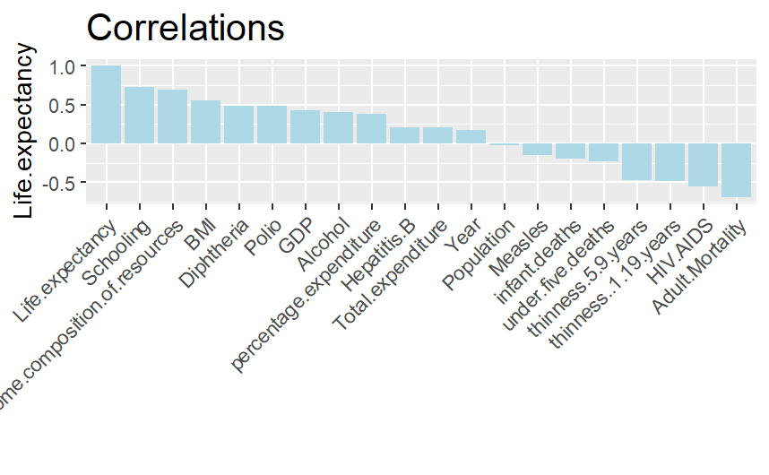

```r
corr_delay <- sort(cor(Train[,c(3:22)])["Life.expectancy",], decreasing = T)
corr=data.frame(corr_delay)
ggplot(corr,aes(x = row.names(corr), y = corr_delay)) +
  geom_bar(stat = "identity", fill = "lightblue") +
  scale_x_discrete(limits= row.names(corr)) +
  labs(x = "", y = "Life.expectancy", title = "Correlations") +
  theme(plot.title = element_text(hjust = 0, size = rel(1.5)),
        axis.text.x = element_text(angle = 45, hjust = 1))
```

#### Life.expectancy and Adult.Mortality, HIV.AIDS, Schooling and Income.composition.of.resources

As mentioned earlier, building potent predictive models using just a single variable is possible. The subsequent series of plots depict the regression model for each highly correlated variable individually. While these models effectively capture a significant portion of the points distribution, it’s evident that some information remains untapped. Considering all four of these variables, and possibly more, could contribute to constructing a more robust and comprehensive prediction algorithm.

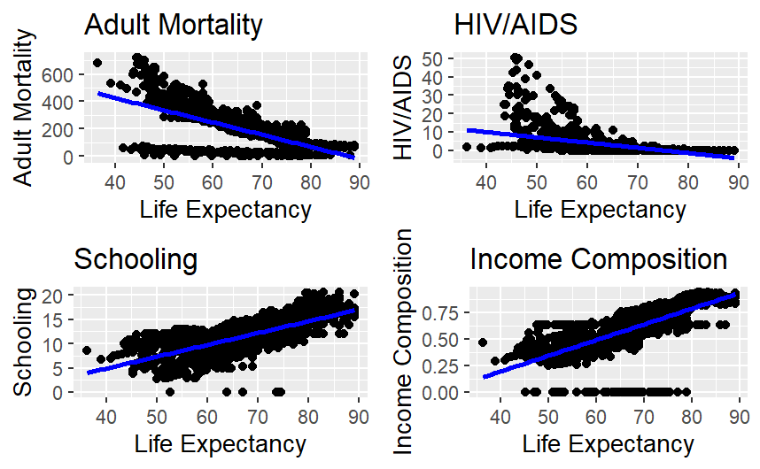

```r
# Plot for Adult.Mortality
plot1 <- ggplot(Train, aes(x = Life.expectancy, y = Adult.Mortality)) +
  geom_point() +
  geom_smooth(method = "lm", se = FALSE, color = "blue") +
  labs(title = "Adult Mortality", x = "Life Expectancy", y = "Adult Mortality")

# Plot for HIV.AIDS
plot2 <- ggplot(Train, aes(x = Life.expectancy, y = HIV.AIDS)) +
  geom_point() +
  geom_smooth(method = "lm", se = FALSE, color = "blue") +
  labs(title = "HIV/AIDS", x = "Life Expectancy", y = "HIV/AIDS")

# Plot for Schooling
plot3 <- ggplot(Train, aes(x = Life.expectancy, y = Schooling)) +
  geom_point() +
  geom_smooth(method = "lm", se = FALSE, color = "blue") +
  labs(title = "Schooling", x = "Life Expectancy", y = "Schooling")

# Plot for Income.composition.of.resources
plot4 <- ggplot(Train, aes(x = Life.expectancy, y = Income.composition.of.resources)) +
  geom_point() +
  geom_smooth(method = "lm", se = FALSE, color = "blue") +
  labs(title = "Income Composition", x = "Life Expectancy", y = "Income Composition")

# Combine the plots into a 2x2 grid
grid.arrange(plot1, plot2, plot3, plot4, ncol = 2)
```

```r
NA
NA
```

#### Life.expectancy and Status

Finally, due to the inability to compute correlation between categorical and numeric variables, the figure below illustrates how the “Status” variable encapsulates significant information about the target variable. The distinct distributions observed for each class suggest that incorporating this variable into the final model would likely be beneficial.

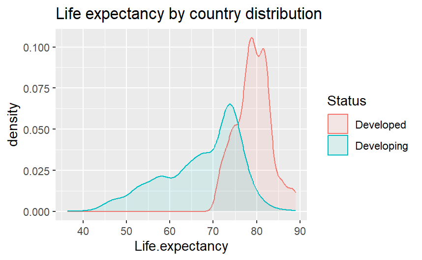

```r
ggplot(Train, aes(Life.expectancy)) + geom_density(aes(group=Status, colour=Status, fill=Status), alpha=0.1) + ggtitle("Life expectancy by country distribution")
```

# 3. Benchmark

As observed, this problem is not inherently complicated, given the substantial correlations between certain variables and the target. Then, to establish a baseline for model improvement, we will utilize a straightforward approach: predicting with the mean of the target variable. This baseline yields an RMSE of $9.89$. The goal is to develop a model that surpasses this baseline performance.

```r
mean(Train$Life.expectancy)
```

```
[1] 69.46535
```

```r
# This is equivalent to
benchFit <- lm(Life.expectancy ~ 1, data=Train)
predictions <- predict(benchFit, newdata=Test) ## we squared the predictions as the transformation in sqrt
RMSE <- sqrt(mean((predictions - Test$Life.expectancy)^2))
RMSE
```

```
[1] 9.892633
```

# 4. Multiple regression algorithms

## 4.1. Overffited model

In the initial steps of creating a model compatible with statistical tools and machine learning methods, we’ll start by constructing an overfitted linear regressor using all variables, without considering interactions. Subsequently, our aim is to refine and select a more optimal model for further analysis.

```r
# If we want to fix the hyper-parameters (no tuning), then no trainControl is needed

ctrl <- trainControl(method = "none")

ModelO = Life.expectancy ~ .

lm_tune <- train(ModelO, data = Train,
                 method = "lm",
                preProc=c('scale', 'center'),
                 trControl = ctrl)
lm_tune
```

```
Linear Regression

2312 samples
  21 predictor

Pre-processing: scaled (200), centered (200)
Resampling: None
```

```r
test_results <- data.frame(Life.expectancy = Test$Life.expectancy)

test_results$lm_1 <- predict(lm_tune, Test)


observed = Test$Life.expectancy
# computes RMSE, R2 and MAE
x= postResample(pred = test_results$lm_1,  obs = observed)
x
```

```
     RMSE  Rsquared       MAE
1.9397214 0.9615831 1.2352866
```

```r
metric_results <- data.frame(Method= "Overfitted", RMSE = x[1], R2 = x[2], MAE = x[3], stringsAsFactors = FALSE)
```

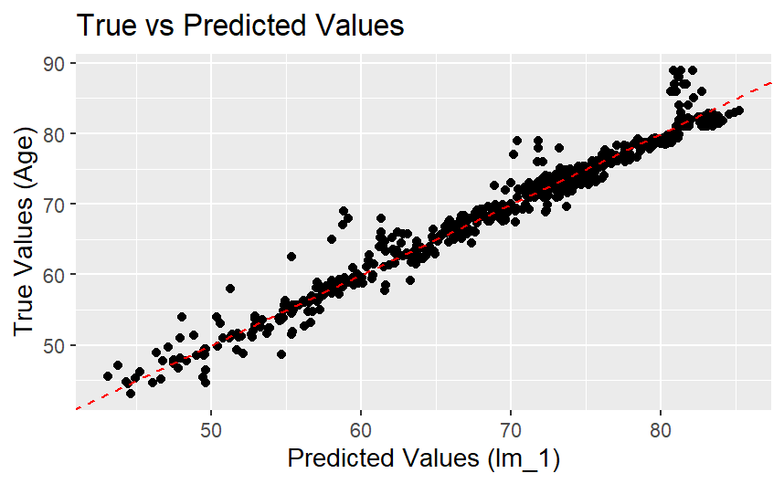

```r
ggplot(test_results, aes(x = lm_1, y = Life.expectancy)) +
  geom_point() +
  geom_abline(intercept = 0, slope = 1, color = "red", linetype = "dashed") +  # Add a reference line (y = x)
  labs(title = "True vs Predicted Values",
       x = "Predicted Values (lm_1)",
       y = "True Values (Age)")
```

As anticipated, the overfitted nature of this model makes it challenging to interpret, yet it demonstrates remarkable predictive performance. The metrics reveal an RMSE of $1.94$ and an R-squared value of $0.96$, indicating that, despite its complexity, the model performs exceptionally well in making accurate predictions. While the interpretability may be compromised due to overfitting, these impressive metrics provide a strong foundation for further refining our model.

## 4.2. Best model

Taking into account the variables analysis, insights from the overfitted model, and observed correlations, our final model is constructed as follows:
$$Model=
Status*Schooling^2 + Adult.Mortality*HIV.AIDS
+ Income.composition.of.resources + BMI + log(Diphtheria) + log(Polio)
+ Alcohol*percentage.expenditure +
thinness..1.19.years*thinness.5.9.years$$
In the model-building process, we initially selected the most correlated variables, opting for a diverse set to allow for potential improvements through model selection methods. Next, by introducing interactions between variables, we aimed to capture additional information within the context of complex variable relationships. Finally, transformations were applied to certain variables to address distribution characteristics.

The resulting final model exhibits $RMSE= 4.09$ and $R^2=0.83$. While these metrics provide a solid foundation, our objective in the subsequent sections will be to further enhance and refine the model’s predictive capabilities.

```r
Model = Life.expectancy ~ Status*Schooling^2 + Adult.Mortality*HIV.AIDS +  Income.composition.of.resources + BMI + log(Diphtheria) + log(Polio) + Alcohol*percentage.expenditure + thinness..1.19.years*thinness.5.9.years

lm_tune <- train(Model, data = Train,
                 method = "lm",
                 preProc=c('scale', 'center'),
                 trControl = ctrl)
lm_tune
```

```
Linear Regression

2312 samples
  12 predictor

Pre-processing: scaled (16), centered (16)
Resampling: None
```

```r
test_results$lm_2 <- predict(lm_tune, Test)
x= postResample(pred = test_results$lm_2,  obs = observed)
x
```

```
     RMSE  Rsquared       MAE
4.0893124 0.8294968 3.0875990
```

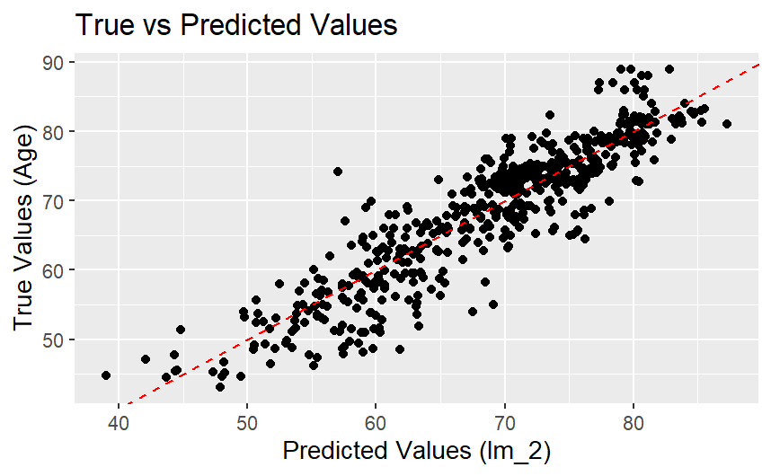

```r
new_method_results <- c("Multiple Reg", x[1], x[2], x[3])

# Add the new row to the metric_results using rbind
metric_results <- rbind(metric_results, new_method_results)

# Create a scatter plot
ggplot(test_results, aes(x = lm_2, y = Life.expectancy)) +
  geom_point() +
  geom_abline(intercept = 0, slope = 1, color = "red", linetype = "dashed") +  # Add a reference line (y = x)
  labs(title = "True vs Predicted Values",
       x = "Predicted Values (lm_2)",
       y = "True Values (Age)")
```

# 5. Statistical Learning Tools

Stadistical learning tools are based on methods that combine statistics and machine learning to make sense of complex datasets.It’s a practical approach that helps us extract useful information, make informed decisions, and create models that work well with new data. In this section, we’ll focus on two key aspects: model selection and regularization methods.

## 5.1. Model selection

Model selection involves choosing the most appropriate variables or features for our model, aiming to strike a balance between simplicity and predictive accuracy. In this context, we’ll explore three widely-used techniques: forward regression, backward regression, and stepwise regression.

### 5.1.1. Forward regression

Forward regression is a method where the model starts with an empty set of predictors and iteratively adds the most impactful variables one at a time. This process continues until a predetermined stopping criterion is met, resulting in a final model with a subset of the available predictors.

Utilizing the *caret* library, we employ a forward regression model trained with 5-fold cross-validation. We configure the model to consider a range of variables, specifically from 4 to 10, to prevent the risk of overfitting due to an excessive number of variables.

```r
Model = Life.expectancy ~ Status*Schooling^2 + Adult.Mortality*HIV.AIDS +  Income.composition.of.resources + BMI + Diphtheria + Polio + Alcohol*percentage.expenditure + thinness..1.19.years*thinness.5.9.years

ctrl <- trainControl(method = "repeatedcv",
                     number = 5, repeats = 1)


for_tune <- train(Model, data = Train,
                  method = "leapForward",
                  preProc=c('scale', 'center'),
                  tuneGrid = expand.grid(nvmax = 4:10),
                  trControl = ctrl)

for_tune
```

```
Linear Regression with Forward Selection

2312 samples
  12 predictor

Pre-processing: scaled (16), centered (16)
Resampling: Cross-Validated (5 fold, repeated 1 times)
Summary of sample sizes: 1848, 1851, 1850, 1850, 1849
Resampling results across tuning parameters:

  nvmax  RMSE      Rsquared   MAE
   4     4.474799  0.7746243  3.189223
   5     4.263140  0.7953881  3.084024
   6     4.181529  0.8030039  2.997116
   7     4.125538  0.8081259  2.996701
   8     4.058275  0.8142742  2.963165
   9     4.011078  0.8185205  2.946938
  10     3.988242  0.8205318  2.935048

RMSE was used to select the optimal model using
 the smallest value.
The final value used for the model was nvmax = 10.
```

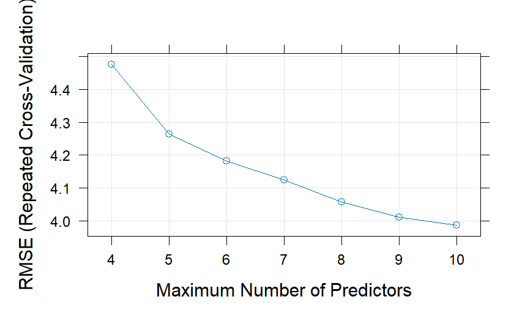

```r
plot(for_tune)
```

As illustrated in the figures, this method opts for 10 variables as the optimal approach. We experimented with a broader tune grid, and the method consistently favored having more variables as the preferred choice. This tendency could be attributed to our original model having several crucial variables for prediction. However, as demonstrated in the subsequent code snippet, the prediction metrics closely resemble those of the original model with all predictors (16), even when considering only 10. This reaffirms that forward regression has indeed identified the most suitable set of predictors. The next question naturally arises: which variables have been selected?

- Schooling
- percentage.expenditure
- Polio
- HIV.AIDS
- BMI
- Adult.Mortality:HIV.AIDS
- StatusDeveloping
- Adult.Mortality
- Income.composition.of.resources
- Diphtheria

```r
coef(for_tune$finalModel, for_tune$bestTune$nvmax)
```

```
                    (Intercept)
                     69.4653547
               StatusDeveloping
                     -0.6239486
                      Schooling
                      2.3239504
                Adult.Mortality
                     -3.2197145
                       HIV.AIDS
                     -4.1311238
Income.composition.of.resources
                      1.1508939
                            BMI
                      0.8681908
                     Diphtheria
                      0.8826611
                          Polio
                      0.7407171
         percentage.expenditure
                      0.4938810
       Adult.Mortality:HIV.AIDS
                      2.3416651
```

Despite employing fewer predictors, the metric results remain largely consistent with the original model. This affirms the effectiveness of this model selection approach in reducing model complexity while retaining robust predictive capabilities.

```r
## when predicting we directly use for_tune as there the correct parameters are saved after training wit CV
test_results$frw <- predict(for_tune, Test)
x= postResample(pred = test_results$frw,  obs = observed)

new_method_results <- c("Forward", x[1], x[2], x[3])

# Add the new row to the metric_results using rbind
metric_results <- rbind(metric_results, new_method_results)
metric_results
```

|  | Method | RMSE | R2 | MAE |
| --- | --- | --- | --- | --- |
| RMSE | Overfitted | 1.93972144987435 | 0.961583138287664 | 1.2352865999172 |
| 2 | Multiple Reg | 4.08931236102052 | 0.829496804264983 | 3.08759902504092 |
| 3 | Forward | 4.15528661851807 | 0.823855948404282 | 3.15505694386849 |

In conclusion, we can now observe the distribution of our model predictions in comparison to the actual data values.

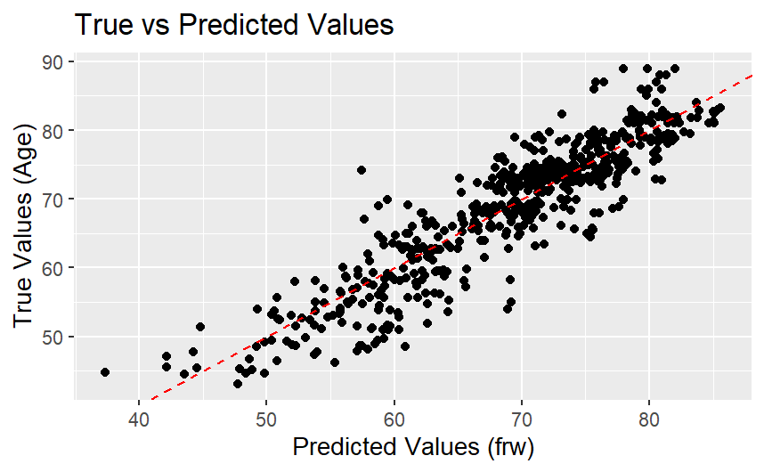

```r
# Create a scatter plot
ggplot(test_results, aes(x = frw, y = Life.expectancy)) +
  geom_point() +
  geom_abline(intercept = 0, slope = 1, color = "red", linetype = "dashed") +  # Add a reference line (y = x)
  labs(title = "True vs Predicted Values",
       x = "Predicted Values (frw)",
       y = "True Values (Age)")
```

### 5.1.2. Backward regression

Backward regression begins with the full set of predictors and removes the least significant variables in a stepwise fashion. This iterative elimination process continues until the model reaches the desired level of simplicity or until certain statistical criteria are satisfied. Similarly to previous method, we use a 5-fold cross-validation with a grid search space of 4 to 10 predictors.

```r
back_tune <- train(Model, data = Train,
                   method = "leapBackward",
                   preProc=c('scale', 'center'),
                   tuneGrid = expand.grid(nvmax = 4:10),
                   trControl = ctrl)
back_tune
```

```
Linear Regression with Backwards Selection

2312 samples
  12 predictor

Pre-processing: scaled (16), centered (16)
Resampling: Cross-Validated (5 fold, repeated 1 times)
Summary of sample sizes: 1849, 1849, 1850, 1850, 1850
Resampling results across tuning parameters:

  nvmax  RMSE      Rsquared   MAE
   4     4.543476  0.7666463  3.253746
   5     4.375121  0.7846186  3.099726
   6     4.226774  0.7991110  3.044068
   7     4.163878  0.8050933  2.989171
   8     4.107639  0.8104129  2.954061
   9     4.069679  0.8138929  2.942736
  10     4.035399  0.8170124  2.928821

RMSE was used to select the optimal model using
 the smallest value.
The final value used for the model was nvmax = 10.
```

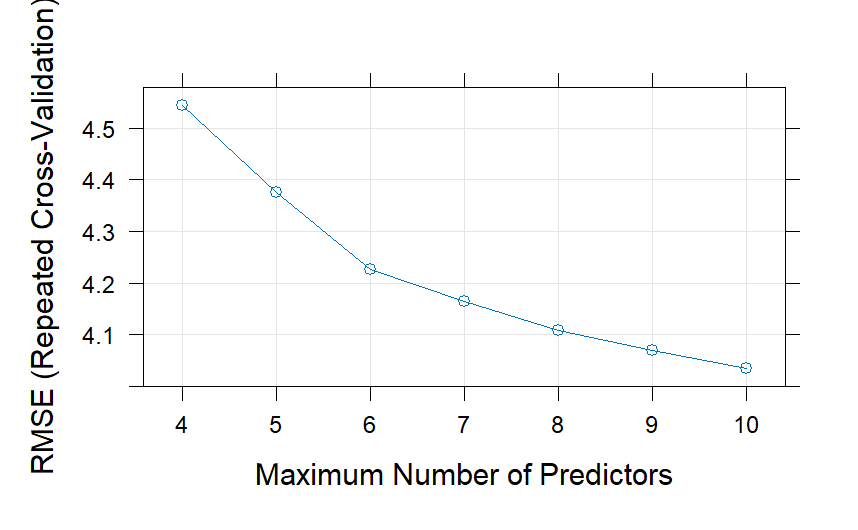

```r
plot(back_tune)
```

Again, when experimenting with a broader tune grid, the method consistently favored having more variables as the preferred choice. However, is important to notice that the set of selected predictors is different with this model:

- StatusDeveloping
- Adult.Mortality
- HIV.AIDS
- Income.composition.of.resources
- Diphtheria
- Polio
- thinness..1.19.years
- StatusDeveloping:Schooling
- Adult.Mortality:HIV.AIDS
- thinness..1.19.years:thinness.5.9.years

```r
coef(back_tune$finalModel, back_tune$bestTune$nvmax)
```

```
                            (Intercept)
                             69.4653547
                       StatusDeveloping
                             -5.1640489
                        Adult.Mortality
                             -3.2453312
                               HIV.AIDS
                             -4.0759684
        Income.composition.of.resources
                              1.3704371
                             Diphtheria
                              0.8065455
                                  Polio
                              0.7757513
                   thinness..1.19.years
                             -2.0735462
             StatusDeveloping:Schooling
                              3.9683119
               Adult.Mortality:HIV.AIDS
                              2.3961004
thinness..1.19.years:thinness.5.9.years
                              1.4440125
```

```r
test_results$bw <- predict(back_tune, Test)
x= postResample(pred = test_results$bw,  obs = observed)
new_method_results <- c("Backward", x[1], x[2], x[3])

# Add the new row to the metric_results using rbind
metric_results <- rbind(metric_results, new_method_results)
metric_results
```

|  | Method | RMSE | R2 | MAE |
| --- | --- | --- | --- | --- |
| RMSE | Overfitted | 1.93972144987435 | 0.961583138287664 | 1.2352865999172 |
| 2 | Multiple Reg | 4.08931236102052 | 0.829496804264983 | 3.08759902504092 |
| 3 | Forward | 4.15528661851807 | 0.823855948404282 | 3.15505694386849 |
| 4 | Backward | 4.07945914040286 | 0.830470567692453 | 3.07928994697362 |

Finally, we visualize the predictions.

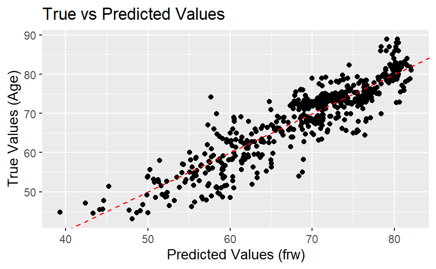

```r
ggplot(test_results, aes(x = bw, y = Life.expectancy)) +
  geom_point() +
  geom_abline(intercept = 0, slope = 1, color = "red", linetype = "dashed") +  # Add a reference line (y = x)
  labs(title = "True vs Predicted Values",
       x = "Predicted Values (frw)",
       y = "True Values (Age)")
```

### 5.1.3. Stepwise regression

Stepwise regression combines elements of both forward and backward regression. It evaluates variables in a stepwise manner, considering their addition or removal at each iteration based on statistical criteria. This iterative approach aims to find an optimal balance between model complexity and performance.

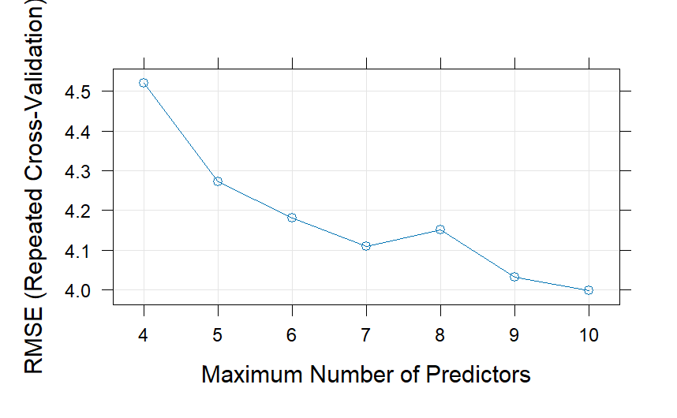

```r
step_tune <- train(Model, data = Train,
                   method = "leapSeq",
                   preProc=c('scale', 'center'),
                   tuneGrid = expand.grid(nvmax = 4:10),
                   trControl = ctrl)
plot(step_tune)
```

```r
# which variables are selected?
coef(step_tune$finalModel, step_tune$bestTune$nvmax)
```

```
                    (Intercept)
                     69.4653547
               StatusDeveloping
                     -5.1696207
                Adult.Mortality
                     -3.1947381
                       HIV.AIDS
                     -4.1067909
Income.composition.of.resources
                      1.1856664
                            BMI
                      0.8117553
                     Diphtheria
                      0.8170589
                          Polio
                      0.7208344
         percentage.expenditure
                      0.6793140
     StatusDeveloping:Schooling
                      3.9717443
       Adult.Mortality:HIV.AIDS
                      2.3149747
```

```r
test_results$seq <- predict(step_tune, Test)
x= postResample(pred = test_results$seq,  obs = observed)
new_method_results <- c("Step", x[1], x[2], x[3])

# Add the new row to the metric_results using rbind
metric_results <- rbind(metric_results, new_method_results)
metric_results
```

|  | Method | RMSE | R2 | MAE |
| --- | --- | --- | --- | --- |
| RMSE | Overfitted | 1.93972144987435 | 0.961583138287664 | 1.2352865999172 |
| 2 | Multiple Reg | 4.08931236102052 | 0.829496804264983 | 3.08759902504092 |
| 3 | Forward | 4.15528661851807 | 0.823855948404282 | 3.15505694386849 |
| 4 | Backward | 4.07945914040286 | 0.830470567692453 | 3.07928994697362 |
| 5 | Step | 4.11563728629476 | 0.827416174734857 | 3.12256520645944 |

## 5.2. Regularization methods

Regularization methods offer a strategic approach to fine-tune models by controlling the impact of individual variables or features. In this exploration, we delve into three prominent regularization techniques: Ridge regression, Lasso regression, and Elastic Net. Much like the strategies employed in model selection, these methods aim to enhance model performance while mitigating the risk of overfitting, providing a nuanced perspective on variable inclusion in predictive modeling.

### 5.2.1. Ridge

Ridge regression, also known as L2 regularization, is a technique used in linear regression to address multicollinearity among predictor variables. Multicollinearity occurs when two or more independent variables in a regression model are highly correlated, leading to unstable and unreliable coefficient estimates. Ridge regression introduces a regularization term to the ordinary least squares (OLS) objective function, which penalizes large coefficients. This regularization term, controlled by a hyperparameter (usually denoted as lambda or alpha), encourages the model to shrink or “regularize” the coefficients towards zero. By doing so, ridge regression mitigates the impact of multicollinearity, stabilizing the model and often improving its generalization performance on new, unseen data.

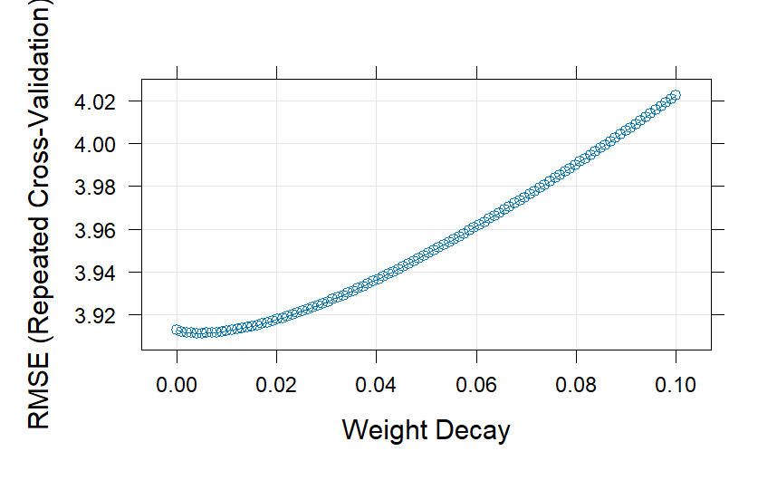

```r
# the grid for lambda (penalization parameter)
ridge_grid <- expand.grid(lambda = seq(0, .1, length = 100))

# train
ridge_tune <- train(Model, data = Train,
                    method='ridge',
                    preProc=c('scale','center'),
                    tuneGrid = ridge_grid,
                    trControl=ctrl)
plot(ridge_tune)
```

```r
NA
NA
NA
```

Finally, during the training process, a low lambda value was selected, indicating minimal penalization for multicollinearity. Despite this modest penalty, empirical evidence from prediction metrics demonstrates that this approach effectively enhances the model’s predictive performance.

```r
# the best tune
ridge_tune$bestTune
```

|  | lambda |
| --- | --- |
| 6 | 0.005050505 |

```r
# prediction
test_results$ridge <- predict(ridge_tune, Test)

x= postResample(pred = test_results$ridge,  obs = observed)
new_method_results <- c("Ridge", x[1], x[2], x[3])

# Add the new row to the metric_results using rbind
metric_results <- rbind(metric_results, new_method_results)
metric_results
```

|  | Method | RMSE | R2 | MAE |
| --- | --- | --- | --- | --- |
| RMSE | Overfitted | 1.93972144987435 | 0.961583138287664 | 1.2352865999172 |
| 2 | Multiple Reg | 4.08931236102052 | 0.829496804264983 | 3.08759902504092 |
| 3 | Forward | 4.15528661851807 | 0.823855948404282 | 3.15505694386849 |
| 4 | Backward | 4.07945914040286 | 0.830470567692453 | 3.07928994697362 |
| 5 | Step | 4.11563728629476 | 0.827416174734857 | 3.12256520645944 |
| 6 | Ridge | 4.04093004760603 | 0.833434393388042 | 3.0849893530783 |

### 5.2.2. Lasso

Lasso regression, or L1 regularization, is a technique employed in linear regression to address multicollinearity and perform feature selection. Similar to ridge regression, lasso introduces a regularization term to the ordinary least squares (OLS) objective function. However, in lasso, the regularization term is based on the absolute values of the regression coefficients, encouraging sparsity by pushing some coefficients to exactly zero. This results in automatic feature selection, as variables with zero coefficients are effectively excluded from the model.

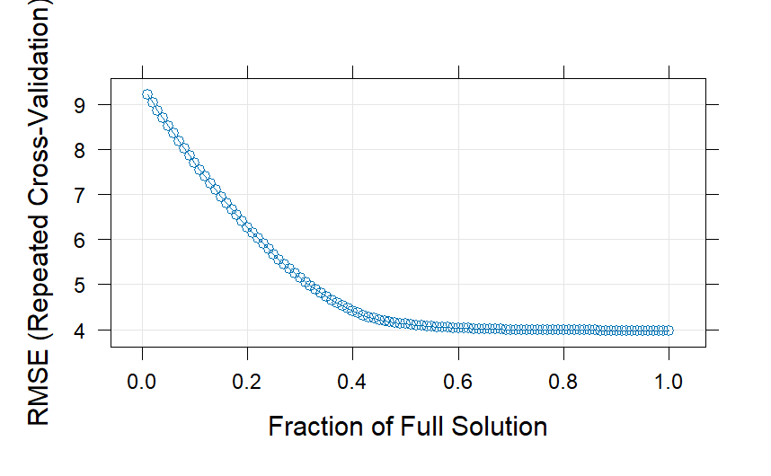

```r
lasso_grid <- expand.grid(fraction = seq(.01, 1, length = 100))

lasso_tune <- train(Model, data = Train,
                    method='lasso',
                    preProc=c('scale','center'),
                    tuneGrid = lasso_grid,
                    trControl=ctrl)
plot(lasso_tune)
```

```r
lasso_tune$bestTune
```

|  | fraction |
| --- | --- |
| 94 | 0.94 |

```r
NA
NA
```

```r
lasso_grid <- expand.grid(fraction = 0.6)  # Assuming 'fraction' is the parameter for Lasso

lasso <- train(Model, data = Train,
                    method='lasso',
                    preProc=c('scale','center'),
                    tuneGrid = lasso_grid,
                    trControl=trainControl(method = "none"))

test_results$lasso <- predict(lasso, Test)
x= postResample(pred = test_results$lasso,  obs = observed)
new_method_results <- c("Lasso", x[1], x[2], x[3])

# Add the new row to the metric_results using rbind
metric_results <- rbind(metric_results, new_method_results)
metric_results
```

|  | Method | RMSE | R2 | MAE |
| --- | --- | --- | --- | --- |
| RMSE | Overfitted | 1.93972144987435 | 0.961583138287664 | 1.2352865999172 |
| 2 | Multiple Reg | 4.08931236102052 | 0.829496804264983 | 3.08759902504092 |
| 3 | Forward | 4.15528661851807 | 0.823855948404282 | 3.15505694386849 |
| 4 | Backward | 4.07945914040286 | 0.830470567692453 | 3.07928994697362 |
| 5 | Step | 4.11563728629476 | 0.827416174734857 | 3.12256520645944 |
| 6 | Ridge | 4.04093004760603 | 0.833434393388042 | 3.0849893530783 |
| 7 | Lasso | 4.19373619854935 | 0.820890301827986 | 3.20234994153209 |

### 5.2.3. Elastic Net

Elastic Net is a regularization technique used in linear regression and machine learning to address the limitations of both Ridge (L2 regularization) and Lasso (L1 regularization). It combines the penalty terms of both methods, introducing two hyperparameters (alpha and lambda) to control the extent of regularization. The alpha parameter balances the contribution of L1 and L2 penalties, allowing Elastic Net to capture the advantages of both methods.

In conclusion, the evaluation metrics for prediction accuracy align with outcomes observed when utilizing Ridge regularization alone.

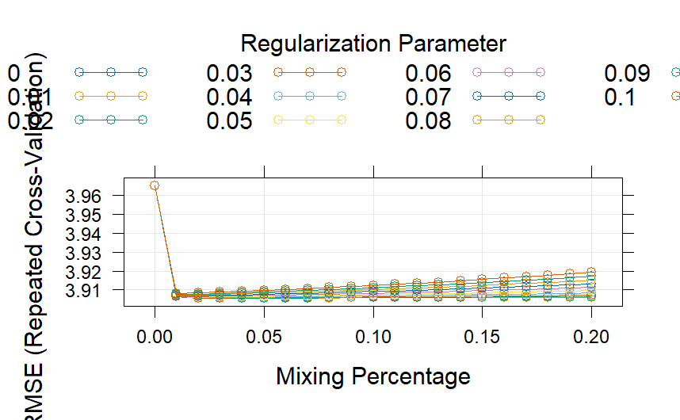

```r
# two parameters, 2D grid
elastic_grid = expand.grid(alpha = seq(0, .2, 0.01), lambda = seq(0, .1, 0.01))

glmnet_tune <- train(Model, data = Train,
                     method='glmnet',
                     preProc=c('scale','center'),
                     tuneGrid = elastic_grid,
                     trControl=ctrl)

plot(glmnet_tune)
```

```r
glmnet_tune$bestTune
```

|  | alpha | lambda |
| --- | --- | --- |
| 47 | 0.04 | 0.02 |

```r
test_results$glmnet <- predict(glmnet_tune, Test)

x= postResample(pred = test_results$glmnet,  obs = observed)
new_method_results <- c("Elastic Net", x[1], x[2], x[3])

# Add the new row to the metric_results using rbind
metric_results <- rbind(metric_results, new_method_results)
```

## 5.3. Interpretation and prediction intervals

After training models using various statistical learning methods, we will select the best-performing model for interpretation and interval computation.

Specifically, Elastic Net has emerged as the most effective method, closely followed by Ridge. Consequently, the final statistical tool selected for our model is Ridge, as the marginal improvement in prediction accuracy offered by Elastic Net is deemed insufficient to justify the added complexity it introduces. In summary, Ridge regularization stands out as the preferred approach for our model.

```r
metric_results
```

|  | Method | RMSE | R2 | MAE |
| --- | --- | --- | --- | --- |
| RMSE | Overfitted | 1.93972144987435 | 0.961583138287664 | 1.2352865999172 |
| 2 | Multiple Reg | 4.08931236102052 | 0.829496804264983 | 3.08759902504092 |
| 3 | Forward | 4.15528661851807 | 0.823855948404282 | 3.15505694386849 |
| 4 | Backward | 4.07945914040286 | 0.830470567692453 | 3.07928994697362 |
| 5 | Step | 4.11563728629476 | 0.827416174734857 | 3.12256520645944 |
| 6 | Ridge | 4.04093004760603 | 0.833434393388042 | 3.0849893530783 |
| 7 | Lasso | 4.19373619854935 | 0.820890301827986 | 3.20234994153209 |
| 8 | Elastic Net | 4.0372737692261 | 0.833842130128603 | 3.07954183618683 |

If we remember the Ridge regularization, it adds a penalty term to the sum of squared coefficients, which results in the coefficients being shrunk towards zero. The small lambda (like 0.005) implies less aggressive shrinkage, allowing the model to retain more of the original features. Furthermore, Ridge regression helps in controlling the trade-off between bias and variance. A low lambda strikes a balance where the model is not too biased (underfit) or too sensitive to the noise in the data (overfit). Finally, since a lower lambda allows the model to retain more features, it tends to be more complex than a model with higher lambda. However, the regularization still helps prevent the model from becoming too complex.

To conclude with the stadistical learning tools section, we plot the prediction intervals of the chosen model by conformal prediction. Conformal prediction is a framework in machine learning that provides valid prediction intervals for individual predictions. It focuses on creating prediction intervals that, on average, contain the true value with a specified confidence level.

- The noise is computed as the difference between the true values (y) and the predicted values (yhat) on the first 100 observations, the calibration set. This represents the initial part of the data used to estimate the noise distribution.
- The lower and upper bounds of the prediction intervals are determined based on the quantiles of the noise (residuals) from the model’s predictions.

```r
y = Test$Life.expectancy
yhat = test_results$ridge

error = y-yhat

noise = error[1:100]

lwr = yhat[101:length(yhat)] + quantile(noise,0.05, na.rm=T)
upr = yhat[101:length(yhat)] + quantile(noise,0.95, na.rm=T)

predictions = data.frame(real=y[101:length(y)], fit=yhat[101:length(yhat)], lwr=lwr, upr=upr)

predictions = predictions %>% mutate(out=factor(if_else(real<lwr | real>upr,1,0)))

# how many real observations are out of the intervals?
mean(predictions$out==1)
```

```
[1] 0.07563025
```

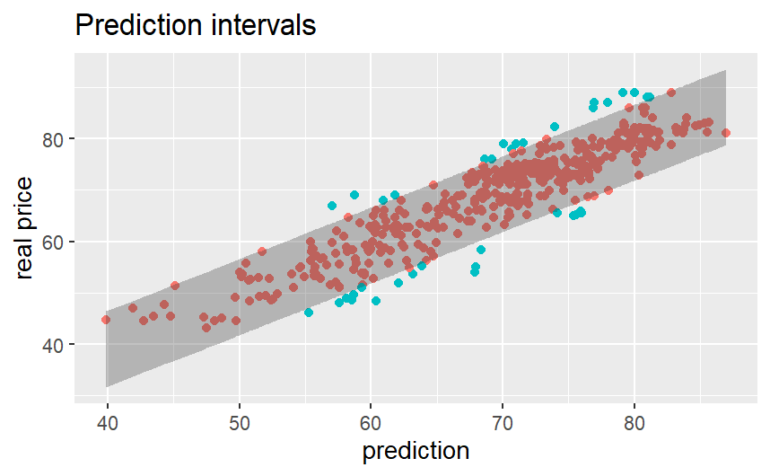

```r
ggplot(predictions, aes(x=fit, y=real))+
  geom_point(aes(color=out)) + theme(legend.position="none") +
  geom_ribbon(data=predictions,aes(ymin=lwr,ymax=upr),alpha=0.3) +
  labs(title = "Prediction intervals", x = "prediction",y="real price")
```

# 6. Machine Learning Tools

Moving forward with the project, we delve into a range of machine learning tools. The tools under consideration span from the straightforward K-Nearest Neighbors (KNN) to the intricacies of gradient boosting and neural networks, encompassing the versatility of methods such as random forests in between. This comparative analysis aims to assess the efficacy and applicability of these diverse machine learning techniques in our project context.

## 6.1. KNN

The K-Nearest Neighbors (KNN) machine learning model operates on the premise that the data itself is the model, making predictions based on the similarity of data points. Among the parameters available for tuning, we opted to assess the values of “k” (the number of neighbors considered) and the choice of distance metric. The search space for “k” was ultimately defined as 1, 3, 5, and 7. Despite experimenting with a larger search space, it was observed that the model selected a larger “k” for optimal performance. However, this larger value resulted in over-generalization, prompting us to narrow down the search space to prevent this issue.

For the distance metric, we focused on tuning the parameter “p” in the Minkowski distance, which generalizes various distance measures. The Minkowski distance is defined as:

$$d(\mathbf{X}, \mathbf{Y}) = \left(
\sum_{i=1}^{n} \lvert X_i - Y_i \rvert^p \right)^{\frac{1}{p}}$$

Here, $\mathbf{X}$ and $\mathbf{Y}$ represent two data points, and $n$ is the number of dimensions. The parameter $p$ allows for flexibility in choosing different distance metrics. Specifically, if $p = 1$, the distance corresponds to the Manhattan distance, and if $p = 2$, it represents the Euclidean distance.

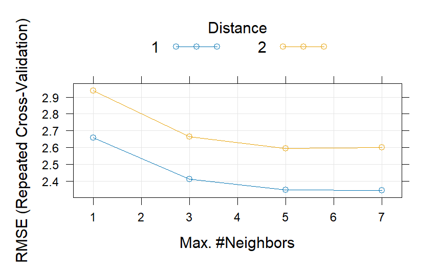

```r
knn_tune <- train(Model,
                  data = Train,
                  method = "kknn",
                  preProc=c('scale','center'),
                  tuneGrid = data.frame(
    kmax = c(1,3,5,7),
    distance = rep(c(1, 2), each = 4),  # Adjusted to have the same number of rows
    kernel = rep('optimal', 16)  # Adjusted to have the same number of rows
  ),
                  trControl = ctrl)
plot(knn_tune)
```

```r
test_results$knn <- predict(knn_tune, Test)

x= postResample(pred = test_results$knn,  obs = observed)

new_method_results <- c("KNN", x[1], x[2], x[3])

# Add the new row to the metric_results using rbind
metric_results <- rbind(metric_results, new_method_results)

knn_tune$bestTune
```

|  | kmax | distance | kernel |
| --- | --- | --- | --- |
| 7 | 7 | 1 | optimal |

```r
metric_results
```

|  | Method | RMSE | R2 | MAE |
| --- | --- | --- | --- | --- |
| RMSE | Overfitted | 1.93972144987435 | 0.961583138287664 | 1.2352865999172 |
| 2 | Multiple Reg | 4.08931236102052 | 0.829496804264983 | 3.08759902504092 |
| 3 | Forward | 4.15528661851807 | 0.823855948404282 | 3.15505694386849 |
| 4 | Backward | 4.07945914040286 | 0.830470567692453 | 3.07928994697362 |
| 5 | Step | 4.11563728629476 | 0.827416174734857 | 3.12256520645944 |
| 6 | Ridge | 4.04093004760603 | 0.833434393388042 | 3.0849893530783 |
| 7 | Lasso | 4.19373619854935 | 0.820890301827986 | 3.20234994153209 |
| 8 | Elastic Net | 4.0372737692261 | 0.833842130128603 | 3.07954183618683 |
| 9 | KNN | 2.2534514994235 | 0.948501699441714 | 1.40684751727889 |

```r
NA
```

## 6.2. Random Forest

The Random Forest method is founded on the concept of an ensemble of trees. Specifically, it constitutes a collection of independently trained trees, incorporating elements of randomization in the process. Random Forest introduces randomness in two main ways. Firstly, it randomly selects a subset of features (variables) at each split in each tree, ensuring diversity among the trees. Secondly, it employs bootstrapped samples (sampling with replacement) from the original dataset to train each tree.

Within the parameters available for tuning using the caret package, two key parameters are notable: - **mtry:** This parameter denotes the number of variables randomly selected to be sampled at each split. - **ntree:** This parameter represents the number of branches that will grow in the ensemble after each split.

For our specific configuration, we opted to set ntree to 100. Setting a moderate number of trees, such as 100, often strikes a satisfactory balance between reducing the risk of overfitting (which can occur with a large number of trees) and maintaining a sufficiently diverse ensemble for robust predictions. This balance is crucial in ensuring the Random Forest model generalizes well to new, unseen data.

As for the mtry parameter, which determines the number of variables randomly selected at each split, we chose to focus our tuning efforts on a limited search space of (1, 3, 5, 7). This choice stems from the desire to explore an adequate range of values without unnecessarily increasing computational complexity. A smaller mtry may result in trees that are more decorrelated, enhancing the diversity of the ensemble, while larger values may introduce more correlated trees. This selective tuning approach helps strike a balance between model complexity and predictive performance, ensuring that the Random Forest method is optimized for the given dataset and problem context.

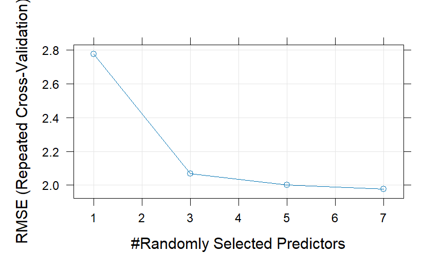

```r
rf_tune <- train(
  Model,
  data = Train,
  method = "rf",
  preProc = c('scale', 'center'),
  trControl = ctrl,
  ntree = 100,
  tuneGrid = expand.grid(
    mtry = c(1, 3, 5, 7)),
  importance = TRUE
)


plot(rf_tune)
```

```r
test_results$rf <- predict(rf_tune, Test)

x=postResample(pred = test_results$rf,  obs = observed)
new_method_results <- c("RF", x[1], x[2], x[3])

# Add the new row to the metric_results using rbind
metric_results <- rbind(metric_results, new_method_results)
metric_results
```

|  | Method | RMSE | R2 | MAE |
| --- | --- | --- | --- | --- |
| RMSE | Overfitted | 1.93972144987435 | 0.961583138287664 | 1.2352865999172 |
| 2 | Multiple Reg | 4.08931236102052 | 0.829496804264983 | 3.08759902504092 |
| 3 | Forward | 4.15528661851807 | 0.823855948404282 | 3.15505694386849 |
| 4 | Backward | 4.07945914040286 | 0.830470567692453 | 3.07928994697362 |
| 5 | Step | 4.11563728629476 | 0.827416174734857 | 3.12256520645944 |
| 6 | Ridge | 4.04093004760603 | 0.833434393388042 | 3.0849893530783 |
| 7 | Lasso | 4.19373619854935 | 0.820890301827986 | 3.20234994153209 |
| 8 | Elastic Net | 4.0372737692261 | 0.833842130128603 | 3.07954183618683 |
| 9 | KNN | 2.2534514994235 | 0.948501699441714 | 1.40684751727889 |
| 10 | RF | 2.05032580419919 | 0.957804398009991 | 1.31410914351852 |

As evident from the observations, the ultimate Random Forest model exhibits superior performance compared to the earlier K-Nearest Neighbors (KNN) approach. This improvement may be attributed to the inherent strengths of the Random Forest methodology, such as its ability to handle complex relationships and mitigate overfitting through ensemble learning.

To gain further insights, considering that this Random Forest model is constructed from a different number of trees, we can visualize the importance of each variable in the specific context of this model. Variable importance is determined by the number of times a variable is chosen as a node across all individual trees within the ensemble. It is crucial to note that these variable importance rankings are specific to this Random Forest model and the dataset it was trained on. Any alterations in the model parameters or changes to the dataset may impact these importance rankings, and therefore, they should be interpreted in the context of this particular model and dataset.

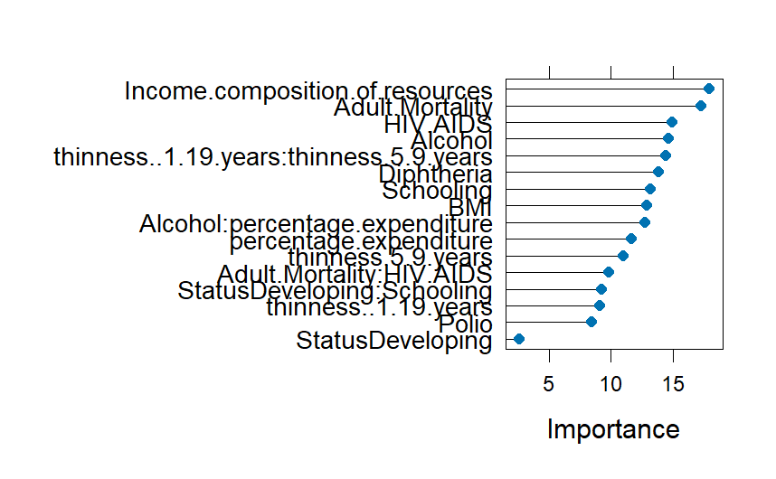

```r
plot(varImp(rf_tune, scale = F), scales = list(y = list(cex = .95)))
```

## 6.3. Gradient Boosting

Gradient Boosting is a machine learning method based on the concept of building a predictive model through the sequential combination of weak learners, typically decision trees. The fundamental idea behind Gradient Boosting is to iteratively improve the model’s predictive performance by focusing on the mistakes made by the previous models in the sequence.

Gradient boosting in caret has many hyperparameters:

- nrounds: This hyperparameter represents the number of boosting rounds or trees to build. It is also known as the number of iterations. A higher value may lead to better performance, but it can also increase the risk of overfitting.
- max_depth: This parameter controls the maximum depth of each tree in the boosting process. A higher value allows the trees to capture more complex relationships in the data, but it may lead to overfitting.
- eta (learning rate): The learning rate controls the contribution of each tree to the final prediction. A smaller learning rate requires more boosting rounds but can lead to better generalization. It’s a regularization technique to prevent overfitting.
- gamma: This parameter controls whether a given node will split based on the expected reduction in loss after the split. It provides regularization by preventing the tree from being too deep.
- colsample_bytree: It represents the fraction of features to be randomly sampled for building each tree. It helps to prevent overfitting by introducing randomness.
- min_child_weight: This parameter controls the minimum sum of instance weight (hessian) needed in a child. It adds regularization to avoid splitting nodes that don’t contribute significantly.
- subsample: This parameter controls the fraction of the training data to be randomly sampled for each boosting round. It introduces randomness and helps prevent overfitting.

```r
xgb_tune <- train(
  Model,
  data = Train,
  method = "xgbTree",
  preProc = c('scale', 'center'),
  trControl = ctrl,
  tuneGrid = expand.grid(
    nrounds = 500,
    max_depth = c(5, 6, 7),
    eta = c(0.01, 0.1, 1),
    gamma = c(1, 2, 3),
    colsample_bytree =0.8,  # Adjusted values to be within [0, 1]
    min_child_weight = 1,
    subsample = 0.8
  )
)


test_results$xgb <- predict(xgb_tune, testing)
```

```
Error: object 'testing' not found
```

```r
test_results$xgb <- predict(xgb_tune, Test)

x= postResample(pred = test_results$xgb,  obs = test_results$Life.expectancy)
new_method_results <- c("GB", x[1], x[2], x[3])

# Add the new row to the metric_results using rbind
metric_results <- rbind(metric_results, new_method_results)
metric_results
```

|  | Method | RMSE | R2 | MAE |
| --- | --- | --- | --- | --- |
| RMSE | Overfitted | 1.93972144987435 | 0.961583138287664 | 1.2352865999172 |
| 2 | Multiple Reg | 4.08931236102052 | 0.829496804264983 | 3.08759902504092 |
| 3 | Forward | 4.15528661851807 | 0.823855948404282 | 3.15505694386849 |
| 4 | Backward | 4.07945914040286 | 0.830470567692453 | 3.07928994697362 |
| 5 | Step | 4.11563728629476 | 0.827416174734857 | 3.12256520645944 |
| 6 | Ridge | 4.04093004760603 | 0.833434393388042 | 3.0849893530783 |
| 7 | Lasso | 4.19373619854935 | 0.820890301827986 | 3.20234994153209 |
| 8 | Elastic Net | 4.0372737692261 | 0.833842130128603 | 3.07954183618683 |
| 9 | KNN | 2.2534514994235 | 0.948501699441714 | 1.40684751727889 |
| 10 | RF | 2.05032580419919 | 0.957804398009991 | 1.31410914351852 |

[output cut: 1 more lines]

Gradient boosting has demonstrated its superiority over other methods thus far, surpassing even the performance of an overfitted linear model. This remarkable achievement can be attributed to its inherent ability to mitigate overfitting, a characteristic ingrained in the model’s nature. This is can be due to the careful hyperparameter tuning performed during the model development, which ensures that the boosting process is constrained and prevents excessive complexity that could lead to overfitting.

Conclusively, we can once again delve into assessing the significance of variables in these specific models, facilitated by the foundational tree models upon which gradient boosting is constructed.

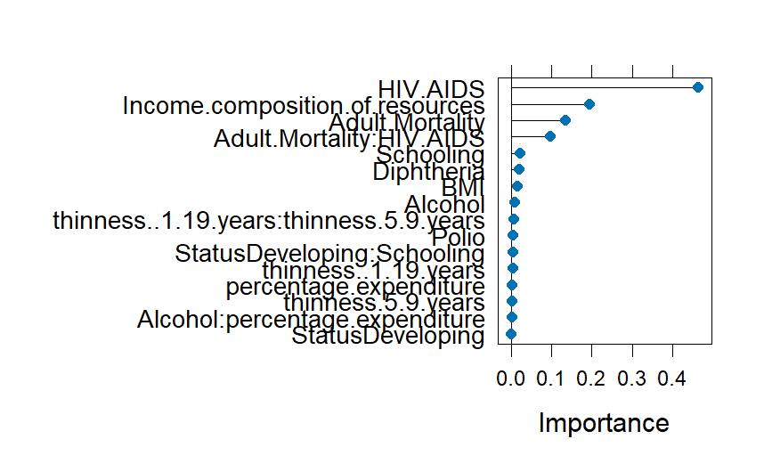

```r
plot(varImp(xgb_tune, scale = F), scales = list(y = list(cex = .95)))
```

```r
NA
NA
```

## 6.4. Neural Networks

Neural networks represent a category of machine learning models inspired by the intricate structure and operations of the human brain. Comprising interconnected nodes, or artificial neurons represented as mathematical functions, these models are organized into layers. The input layer receives initial data, hidden layers process information, and the output layer generates the final result. Neurons are connected with associated weights and biases, which are fine-tuned through the training process, enabling the network to adapt and make precise predictions.

Specifically, in this context, we are fine-tuning a neural network with three layers, aiming to identify the optimal combination of neurons for each layer. Given the computational intensity of this model, we opt for more conservative search spaces to efficiently explore the potential configurations.

```r
nn_tune <- train(
  Model,
  data = Train,
  method = "neuralnet",
  preProc = c('scale', 'center'),
  trControl = ctrl,
  tuneGrid = expand.grid(
    layer1 = c(2, 3),
    layer2 = c(2, 3),
    layer3 = c(2, 3)
  )
)
test_results$nn <- predict(nn_tune, testing)
```

```
Error: object 'testing' not found
```

```r
test_results$nn <- predict(nn_tune, Test)

x= postResample(pred = test_results$nn,  obs = test_results$Life.expectancy)
new_method_results <- c("NN", x[1], x[2], x[3])

# Add the new row to the metric_results using rbind
metric_results <- rbind(metric_results, new_method_results)
metric_results
```

|  | Method | RMSE | R2 | MAE |
| --- | --- | --- | --- | --- |
| RMSE | Overfitted | 1.93972144987435 | 0.961583138287664 | 1.2352865999172 |
| 2 | Multiple Reg | 4.08931236102052 | 0.829496804264983 | 3.08759902504092 |
| 3 | Forward | 4.15528661851807 | 0.823855948404282 | 3.15505694386849 |
| 4 | Backward | 4.07945914040286 | 0.830470567692453 | 3.07928994697362 |
| 5 | Step | 4.11563728629476 | 0.827416174734857 | 3.12256520645944 |
| 6 | Ridge | 4.04093004760603 | 0.833434393388042 | 3.0849893530783 |
| 7 | Lasso | 4.19373619854935 | 0.820890301827986 | 3.20234994153209 |
| 8 | Elastic Net | 4.0372737692261 | 0.833842130128603 | 3.07954183618683 |
| 9 | KNN | 2.2534514994235 | 0.948501699441714 | 1.40684751727889 |
| 10 | RF | 2.05032580419919 | 0.957804398009991 | 1.31410914351852 |

[output cut: 2 more lines]

Unexpectedly, the neural network exhibits the poorest performance among all the models tested. While this method proves highly effective in certain contexts, it is essential to recognize that neural networks highlight in handling data types like images, voice, or video due to their capability to discern intricate patterns inherent to such data. However, when confronted with tabular data, simpler machine learning methods such as KNN or random forest often outshine neural networks because tabular data typically lacks the complex relationships and non-linear patterns that neural networks are adept at capturing. Simpler methods like KNN or random forest, with their transparency and ease of implementation, often provide more interpretable and reliable results for structured datasets, making them preferable choices in such scenarios.

## 6.5. Interpretation and prediction intervals

After training several machine learning models, we will select the best-performing method for interpretation and interval computation.

The results unequivocally demonstrate that, for our specific problem, Gradient Boosting outperforms the rest of the methods. This superiority can be attributed to its ability to sequentially minimize errors by focusing on the weaknesses of the preceding models, thus capturing intricate patterns and non-linear relationships in the data. Additionally, the hyperparameter tuning process ensured that Gradient Boosting was fine-tuned to the specific characteristics of our dataset, further enhancing its performance. The model’s robustness, coupled with its interpretability, makes it the optimal choice for both understanding the underlying patterns in the data and computing reliable prediction intervals.

```r
metric_results
```

|  | Method | RMSE | R2 | MAE |
| --- | --- | --- | --- | --- |
| RMSE | Overfitted | 1.93972144987435 | 0.961583138287664 | 1.2352865999172 |
| 2 | Multiple Reg | 4.08931236102052 | 0.829496804264983 | 3.08759902504092 |
| 3 | Forward | 4.15528661851807 | 0.823855948404282 | 3.15505694386849 |
| 4 | Backward | 4.07945914040286 | 0.830470567692453 | 3.07928994697362 |
| 5 | Step | 4.11563728629476 | 0.827416174734857 | 3.12256520645944 |
| 6 | Ridge | 4.04093004760603 | 0.833434393388042 | 3.0849893530783 |
| 7 | Lasso | 4.19373619854935 | 0.820890301827986 | 3.20234994153209 |
| 8 | Elastic Net | 4.0372737692261 | 0.833842130128603 | 3.07954183618683 |
| 9 | KNN | 2.2534514994235 | 0.948501699441714 | 1.40684751727889 |
| 10 | RF | 2.05032580419919 | 0.957804398009991 | 1.31410914351852 |

[output cut: 2 more lines]

Therefore, we will finally evaluate the predictions intervals from the Gradient Boosting model. Again, we will employ conformal prediction, which focuses on creating prediction intervals that, on average, contain the true value with a specified confidence level. As a brief review:

- The noise is computed as the difference between the true values (y) and the predicted values (yhat) on the first 100 observations, the calibration set. This represents the initial part of the data used to estimate the noise distribution.
- The lower and upper bounds of the prediction intervals are determined based on the quantiles of the noise (residuals) from the model’s predictions.

```r
y = Test$Life.expectancy
yhat = test_results$xgb

error = y-yhat

noise = error[1:100]

lwr = yhat[101:length(yhat)] + quantile(noise,0.05, na.rm=T)
upr = yhat[101:length(yhat)] + quantile(noise,0.95, na.rm=T)

predictions = data.frame(real=y[101:length(y)], fit=yhat[101:length(yhat)], lwr=lwr, upr=upr)

predictions = predictions %>% mutate(out=factor(if_else(real<lwr | real>upr,1,0)))

# how many real observations are out of the intervals?
mean(predictions$out==1)
```

```
[1] 0.1659664
```

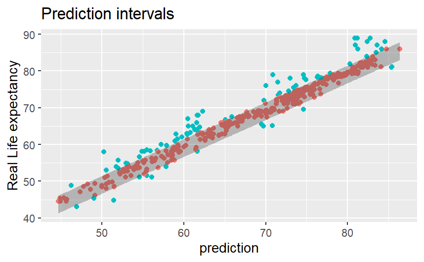

```r
ggplot(predictions, aes(x=fit, y=real))+
  geom_point(aes(color=out)) + theme(legend.position="none") +
  geom_ribbon(data=predictions,aes(ymin=lwr,ymax=upr),alpha=0.3) +
  labs(title = "Prediction intervals", x = "prediction",y="Real Life expectancy")
```

Here, we can observe an interesting phenomenon. The gradient boosting model exhibits superior performance in terms of point predictions on the test set, as evidenced by lower RMSE and higher $R^2$ values. These metrics signify the model’s ability to accurately predict average responses.

To conclude, this divergence in performance underscores the importance of considering multiple evaluation metrics. While gradient boosting highlights in point predictions, the ridge regression model demonstrates a noteworthy advantage in providing well-calibrated prediction intervals. This understanding is crucial for a comprehensive assessment of the models’ effectiveness in different aspects of prediction and uncertainty estimation.